# Data in R

PCB 6455 / BSC 4933: Biometry | Lecture 4

Dr. Brian Maitner

## Today’s agenda

1. File formats, and why plain text
2. Getting data into R: paths, the web, and Excel
3. Metadata, and two ways to lay out the same data
4. Data types: what R thinks your data are
5. Looking inside your data

Type and run on a code block: type it into your script and run it. Code without the label is there to watch.

## The story so far

**Lecture 2:** the choices behind a model, and where its scatter comes from.

**Lecture 3:** three ways to do statistics, and data we simulated ourselves.

**Today:** real data, from a file, and how to tell whether R read it right.

# File formats

## Electronic formats

| Kind | Examples | In R |
| --- | --- | --- |
| Plain text | `.csv`, `.txt` | built in |
| Proprietary | Excel `.xlsx`, ESRI `.shp` | may need a package |
| R’s own | `.RDS` | built in |

Different formats have different pros and cons.

## Why plain text?

**Readable by anything,** on any machine.

**Won’t become obsolete** with the next software version.

**Survives partial corruption:** lose a line, and the rest still reads.

A `.csv` is just a text file whose layout tells you how to read it: csv = comma-separated values.

If you can open it in Notepad and read it, so can anyone, with any software, in twenty years.

## We practice this

| What | Format |
| --- | --- |
| Your assignments | `.R`, `.Rmd`, `.qmd` |
| This course’s syllabus | Markdown |
| The data in `data/` | `.csv` |

These are all basically text files.

**Not an accident!**

# Getting data into R

## Getting data into R

**The function depends on the file type,** and there are often several to choose from.

**R can read from almost anywhere:** your computer, the web, databases.

**Functions can mess things up when importing!** R nearly always reads *something*. Whether it read what you meant is a separate question.

## Example functions

| File type | Extension(s) | Common R import function(s) | Package(s) |
| --- | --- | --- | --- |
| Comma-separated values | `.csv` | `read.csv()`, `read_csv()` | base, readr |
| Tab-delimited text | `.tsv`, `.txt` | `read.delim()`, `read_tsv()` | base, readr |
| Excel | `.xls`, `.xlsx` | `read_excel()`, `read.xlsx()` | readxl, openxlsx (`.xlsx` only) |
| R object (several) | `.RData`, `.rda` | `load()` | base |
| R object (single) | `.RDS` | `readRDS()` | base |
| SPSS | `.sav` | `read.spss()`, `read_sav()` | foreign, haven |
| Stata | `.dta` | `read.dta()`, `read_dta()` | foreign, haven |
| SAS | `.sas7bdat`, `.xpt` | `read_sas()`, `read.xport()` | haven, foreign |
| JSON | `.json` | `fromJSON()` | jsonlite |
| XML | `.xml` | `xmlParse()`, `read_xml()` | XML, xml2 |
| Feather, Parquet | `.feather`, `.parquet` | `read_feather()`, `read_parquet()` | arrow |
| HDF5 | `.h5` | `h5read()` | rhdf5 |
| NetCDF | `.nc` | `nc_open()` | ncdf4 |
| SQLite database | `.sqlite`, `.db` | `dbConnect(RSQLite::SQLite(), ...)` | RSQLite |
| Shapefile, GeoPackage (GIS) | `.shp`, `.gpkg` | `st_read()` | sf |

## Work in a script

Everything today builds on the step before, so keep it in a file you can rerun.

1. **File → New File → R Script**
2. Save it in your project, for example as `lecture_04.R`
3. Run a line, or a selection, with **Ctrl+Enter** (Mac: **Cmd+Enter**)

The console is for quick checks, like `?read.csv`. The script is your record.

## Get the file

1. Go to the course GitHub site: github.com/bmaitner/biometry_course
2. Navigate to **data/Avonet**
3. Download **AVONET1_BirdLife.csv**
4. Save it in your project, in a folder **data/Avonet/**, so your paths match ours

AVONET: measurements of 11,009 bird species.

AVONET: Tobias et al. (2022), *Ecology Letters* 25: 581–597. CC BY 4.0

## Two ways to say where a file is

**Absolute:** the path from the root of your file system.

**Relative:** the path from your working directory (your project folder).

**Which is which?**

`"C:/Users/bmaitner/Desktop/courses/biometry_course/data/Avonet/AVONET1_BirdLife.csv"`

`"data/Avonet/AVONET1_BirdLife.csv"`

The first works only on my computer. The second works on anyone’s, as long as the project is laid out the same way.

## Read it

```r
avonet <- read.csv("data/Avonet/AVONET1_BirdLife.csv")
```

Then try it with the absolute path to the file on your own computer, as `avonet_v2`.

**Tab completion makes it easier:** type `read.csv("")`, put the cursor between the quotes, and press **Tab**.

**Check:** `avonet` has 11,009 rows and 37 columns (see the Environment pane).

## Reading data from the web

Many R functions can also read online data:

```r
avonet_v3 <- read.csv("https://github.com/bmaitner/biometry_course/raw/refs/heads/main/data/Avonet/AVONET1_BirdLife.csv")
identical(avonet, avonet_v3)
```

Same data, two routes.

**Check:** `TRUE`

# When the file fights back

## Not everything is a .csv

Download **data/European_amphibians/oo_32985.xlsx** into the same place, then:

```r
# the wrong function, on purpose: see what R does
amphibians <- read.csv("data/European_amphibians/oo_32985.xlsx")
```

This is an Excel file. Try it anyway.

**What happens? Why?**

## That’s not text

Depending on your computer, a warning or an error:

```
line 1 appears to contain embedded nulls
duplicate 'row.names' are not allowed
```

Either way, `.xlsx` isn’t text. It’s a zip file full of XML.

`read.csv()` reads **text**. It tried.

## You need a package

Base R can’t read Excel files. Someone else wrote code that can.

```r
install.packages("readxl")
```

Needed once per computer, not once per session.

## Installing is not loading

```r
# this fails on purpose: read the error
read_xlsx("data/European_amphibians/oo_32985.xlsx")
```

```
Error: could not find function "read_xlsx"
```

Installed is not the same as available. Load it, with no quotes this time:

```r
library(readxl)
```

`install.packages()` downloads a package to your computer: do it once. `library()` turns it on for this R session: do it every time you open R.

## Now read it

```r
amphibians <- read_xlsx("data/European_amphibians/oo_32985.xlsx")
head(amphibians)
```

R prints a long list of “New names” first. Then the data.

**Did it work?**

## Look at the file first

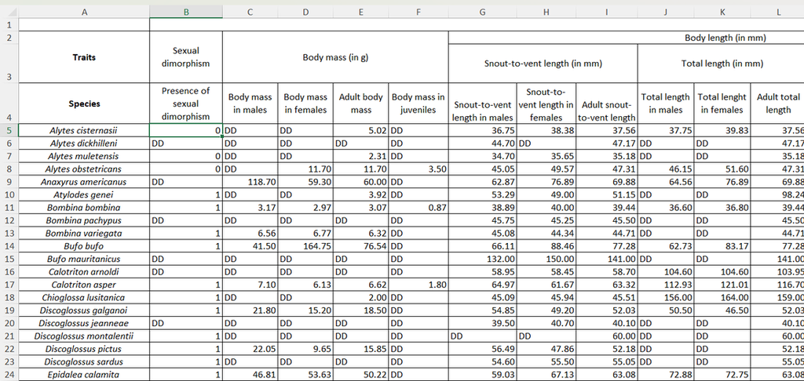

Rows 1 to 3: titles and groupings. Row 4: the actual column names.

Trochet et al. (2014), *Biodiversity Data Journal* 2: e4123. CC0

## Telling R where to start

```r
amphibians <- read_xlsx("data/European_amphibians/oo_32985.xlsx",
                        skip  = 3,
                        sheet = 1,
                        na    = "DD")
head(amphibians)
```

| Argument | Why |
| --- | --- |
| `skip = 3` | ignore the three title rows |
| `sheet = 1` | an Excel file can hold several sheets; use the first |
| `na = "DD"` | “DD” (data deficient) is used instead of NA |

**Check:** 86 species. The first column is `Species`.

# Metadata

## Metadata

Data about data: the information that describes your data.

Variable names. Units. When and where it was collected.

R has no system for this. Keeping it is on **you**.

**Super important to do this well!**

## Column names are metadata

Strike a balance between **clarity** and **brevity**. Which would you rather be given?

`larvdens` `larval_density` `x` `larval_density_per_m3_in_ponds`

**`larval_density`.** `x` says nothing, and the last one is a sentence: units belong in the metadata.

Use underscores or dots. **Never** spaces.

## You can put metadata in the file

The top of a `.csv` can carry notes, marked with `#`:

```
# Amniote traits, Myhrvold et al. 2015
# Missing values coded as -999
species,adult_body_mass_g,longevity_y
...
```

`read.csv()` will not skip those lines on its own. Tell it to:

```r
read.csv("my_traits.csv", comment.char = "#")
```

## What we do in this course

Every folder in `data/` has a README: where the data came from, the license, and any gotchas.

Open **data/Amniote_traits/README** on the course GitHub site.

# Two ways to lay out the same data

## Long format

One row per observation:

| station | date | species | seeds |
| --- | --- | --- | --- |
| 1 | 1999-03-23 | psd | 5 |
| 1 | 1999-03-27 | psd | 5 |
| 2 | 1999-03-23 | uva | 5 |
| 2 | 1999-03-27 | uva | 5 |

Also called skinny, or tidy.

## Wide format

One row per station, dates as columns:

| station | species | 03-23 | 03-27 |
| --- | --- | --- | --- |
| 1 | psd | 5 | 5 |
| 2 | uva | 5 | 5 |

Same data. Most R functions want the long version.

# Data types

## Data types in R

In R, all data have a type:

| Type | Example |
| --- | --- |
| Numeric | `2005` |
| Logical | `TRUE` |
| Character | `"Optimus Prime"` |
| Factor | `"Small"` vs `"Medium"` vs `"Large"` |

To find out what type something is, use **`class()`**.

## Try class()

```r
class("something")
class(1)
class(1L)
class(TRUE)
```

**Check:** `"character"`, `"numeric"`, `"integer"`, `"logical"`

## R guesses, and sometimes gets it very wrong

R tries to guess what type things are. Common mistakes:

| Mix-up | For example |
| --- | --- |
| numeric vs logical | yes/no recorded as 0 and 1, read as numbers |
| date vs character or number | `2015-08-01` read as text |
| factor vs numeric | site numbers 1, 2, 3 treated as amounts |

These mistakes can cause big problems in analyses.

**It’s important to check your data!**

## R read it. Is it right?

Download **data/Amniote_traits/Amniote_Database_Aug_2015.csv**, then:

```r
amniotes <- read.csv("data/Amniote_traits/Amniote_Database_Aug_2015.csv")
mean(amniotes$litter_or_clutch_size_n)
mean(amniotes$longevity_y)
```

**What do you get?**

Myhrvold et al. (2015), *Ecology* 96: 3109. CC BY 4.0

## What happened?

This dataset codes missing values as **−999**. R read them as numbers.

```r
amniotes <- read.csv("data/Amniote_traits/Amniote_Database_Aug_2015.csv",
                     na.strings = -999)
mean(amniotes$litter_or_clutch_size_n, na.rm = TRUE)
```

**Check:** 3.83

We needed metadata to get this right! (It’s in the README.)

## The one that should worry you

```r
mean(amniotes$adult_body_mass_g, na.rm = TRUE)
```

|  | Mean body mass |
| --- | --- |
| Read naively | 29,107 g |
| Read correctly | 37,493 g |

Nothing about the first number looks wrong. No error. No warning. Just wrong.

R reading a file without complaint does not mean it read it right. Check the README, and check the numbers.

# Data structures

## Higher data types

A single value is not often useful. Usually we want sets of data:

| Structure | What it is | One type throughout? |
| --- | --- | --- |
| Vector | the most basic: an ordered set of elements | yes |
| Matrix | a vector in two dimensions | yes |
| Array | a matrix in more dimensions | yes |
| List | an ordered set of objects of any types or lengths | no |
| Data frame | a table: a list of equal-length vectors (the columns) | per column |
| Tibble | a modern data frame, with cleaner printing and stricter rules | per column |

## What is avonet?

`class()` works on these too:

```r
class(avonet)
class(amphibians)
```

**Check:** `"data.frame"`, then `"tbl_df" "tbl" "data.frame"`

## Getting things out: by position

For a vector or a list, you can get elements by their **position**:

```r
test_vector <- c("Optimus Prime", "Megatron")
test_vector[[1]]
test_vector[1]
```

**Check:** both give `"Optimus Prime"`

## Getting things out: by name

```r
test_named_vector <- c("A" = "Optimus Prime",
                       "B" = "Megatron")
test_named_vector[["A"]]
test_named_vector["A"]
names(test_named_vector)
```

`names()` tells you what names there are.

**Check:** `[["A"]]` gives just `"Optimus Prime"`; `["A"]` keeps the name `A` above it.

## Tables have rows and columns

For matrices, data frames and arrays, ask for `x[row, column]`, by name or by number. Leave one blank to get all of it:

```r
x[1, ]          # row 1, every column
x[, "mass"]     # the mass column, every row
x[1, "mass"]    # one value
```

## Same shape, different rules

Data frames and matrices look alike, but work differently:

|  | Data frame | Matrix |
| --- | --- | --- |
| Column names | `names()` or `colnames()` | `colnames()` only |
| One column | `x$a`, `x[["a"]]`, `x[, "a"]` | `x[, "a"]` only |

`class(x)` tells you which one you have.

## Columns of avonet

To get the species names:

```r
head(avonet$Species1)
head(avonet[1])
head(avonet[, 1])
class(avonet[1])
class(avonet[, 1])
```

## Rows of avonet

To get one species:

```r
avonet[1, ]
avonet["1", ]
```

`avonet["1", ]` only works because the first row is **named** `"1"`.

**Check:** both show *Accipiter albogularis*

# Looking inside your data

## Check the types

```r
class(avonet$Species1)
class(avonet[, 2])
```

That’s two columns. There are 37. To see them all at once:

```r
str(avonet)
```

## Reading str()

```
'data.frame':   11009 obs. of  37 variables:
 $ Sequence          : int  3103 3090 3125 3116 3092 ...
 $ Species1          : chr  "Accipiter albogularis" "Accipiter badius" ...
 $ Family1           : chr  "Accipitridae" "Accipitridae" ...
 $ Order1            : chr  "Accipitriformes" "Accipitriformes" ...
 $ Avibase.ID1       : chr  "AVIBASE-BBB59880" "AVIBASE-1A0ECB6E" ...
 $ Total.individuals : int  5 10 11 4 8 ...
 $ Female            : int  2 4 4 4 4 ...
 $ Male              : int  0 6 5 0 4 ...
 $ Unknown           : int  3 0 2 0 0 ...
 $ Complete.measures : int  4 8 8 3 4 ...
  [list output truncated]
```

The class, the size, then one line per column: its **name**, its **type**, and its first values.

## Other quick ways to check

| Function | Shows |
| --- | --- |
| `str()` | the structure of an object |
| `summary()` | summaries, which differ by column type |
| `head()` | the first few rows |
| `table()` | how often each value (or combination) occurs |
| `rownames()`, `colnames()` | row names, column names |

```r
summary(avonet$Beak.Length_Culmen)
table(avonet$Trophic.Level)
colnames(avonet)
```

**Check:** 6,115 carnivores

## What if R gets the type wrong?

Convert between types with the “as” functions: `as.factor()`, `as.character()`, `as.numeric()`, `as.data.frame()`, `as.matrix()`

```r
trophic <- as.factor(avonet$Trophic.Level)
class(trophic)
levels(trophic)
```

**Check:** `"factor"`, with 4 levels

## Dealing with NAs

| You want to | Use |
| --- | --- |
| drop every row that has an NA | `na.omit()` |
| leave NAs out of one calculation | `na.rm` in `mean()`, `na.action` in `lm()`, `use` in `cor()` |
| replace NAs with a value, such as 0 | only when it makes sense, like species seen in a day; we’ll see how later |

## na.omit() is a blunt tool

```r
nrow(avonet)
nrow(na.omit(avonet))
```

**Check:** 11,009, then 36

It drops a row if **any** column is NA. One reference column is mostly empty, so almost every species goes.

# Wrapping up

## Which tool, when

| You want to | Use |
| --- | --- |
| read a .csv | `read.csv()` |
| read an Excel file | `library(readxl)`, then `read_xlsx()` |
| skip title rows, choose a sheet | `skip =`, `sheet =` |
| tell R which values mean missing | `na.strings =` in `read.csv()`, `na =` in `read_xlsx()` |
| leave NAs out of a calculation | `na.rm = TRUE` |
| see what type something is | `class()` |
| see every column at once | `str()`, `summary()`, `head()` |
| count categories | `table()` |
| get a column | `x$a` or `x[, "a"]` |
| fix a type | `as.factor()`, `as.numeric()`, … |

## Before next class

Read Bolker **2.4 to 2.5**

Next class: discuss 2.4 to 2.5 and the data you’re interested in, then work through 2.6